# Gender Roles in Media

Amalin Sorajja

Partners: Clarisa Gomez Faria and Mateo Useche

Due 19 Sept

Potential Research Questions: > a. The difference in revenue of movies with male and female protagonist roles. b. Screen time of male vs. female characters in films with female protagonists. c. Budget difference in male/female protagonists [or male/female audiences]. d. Movie durations differences.

```r
library(ggplot2)
library(readr)
library(tidyverse)
library(dplyr)
library(readxl)
library(ggmosaic)
```

```r
# I really wanted to use this dataset because it had a lot of information on the gender identities of characters as well as writers and directors of 45,000 movies released on or before July 2017. The data was available in the form of a stringified JSON object, which I wanted to parse the data from, but the end of the string in each row was missing the end bracket. I ran into a lot of errors and couldn't get the data to parse because of the improper structure. Never worked with a JSON object before so maybe there is some solution to extract columns that I don't know about.
movies_metadata <- read.csv("credits.csv")
```

```r
imdb <- read.csv("imdb_top_1000.csv")
head(imdb)
```

```
##                                                                                                                                         Poster_Link
## 1 https://m.media-amazon.com/images/M/MV5BMDFkYTc0MGEtZmNhMC00ZDIzLWFmNTEtODM1ZmRlYWMwMWFmXkEyXkFqcGdeQXVyMTMxODk2OTU@._V1_UX67_CR0,0,67,98_AL_.jpg
## 2 https://m.media-amazon.com/images/M/MV5BM2MyNjYxNmUtYTAwNi00MTYxLWJmNWYtYzZlODY3ZTk3OTFlXkEyXkFqcGdeQXVyNzkwMjQ5NzM@._V1_UY98_CR1,0,67,98_AL_.jpg
## 3                                 https://m.media-amazon.com/images/M/MV5BMTMxNTMwODM0NF5BMl5BanBnXkFtZTcwODAyMTk2Mw@@._V1_UX67_CR0,0,67,98_AL_.jpg
## 4 https://m.media-amazon.com/images/M/MV5BMWMwMGQzZTItY2JlNC00OWZiLWIyMDctNDk2ZDQ2YjRjMWQ0XkEyXkFqcGdeQXVyNzkwMjQ5NzM@._V1_UY98_CR1,0,67,98_AL_.jpg
## 5 https://m.media-amazon.com/images/M/MV5BMWU4N2FjNzYtNTVkNC00NzQ0LTg0MjAtYTJlMjFhNGUxZDFmXkEyXkFqcGdeQXVyNjc1NTYyMjg@._V1_UX67_CR0,0,67,98_AL_.jpg
## 6 https://m.media-amazon.com/images/M/MV5BNzA5ZDNlZWMtM2NhNS00NDJjLTk4NDItYTRmY2EwMWZlMTY3XkEyXkFqcGdeQXVyNzkwMjQ5NzM@._V1_UX67_CR0,0,67,98_AL_.jpg
##                                    Series_Title Released_Year Certificate
## 1                      The Shawshank Redemption          1994           A
## 2                                 The Godfather          1972           A
## 3                               The Dark Knight          2008          UA
## 4                        The Godfather: Part II          1974           A
## 5                                  12 Angry Men          1957           U
## 6 The Lord of the Rings: The Return of the King          2003           U
##   Runtime                    Genre IMDB_Rating
```

[output cut: 27 more lines]

This dataset has information on top 1000 movies and TV shows from IMDb, collected by Harshit Shankhdhar, scraping from the IMDb website. It uses IMDb rating for ranking, which is determined by IMDb registered users casting a vote (1 to 10) for each realeased title in the database. It does not have the gender identities of the directors or the top cast members, which would be ideal for the questions we are trying to answer. The dataset includes variables of the title, release year, duration, genre, IMDb rating, meta score (weighted average of many reviews coming from reputed critics), director, {Star1,Star2,Star3,Star4}, and revenue. A couple ideas I have are visualizing the top 10 movies/shows ranked, and looking at the gender identities of the directors and cast manually since we don’t have a gender variable. Also looking at top 10 highest revenue and perhaps duration.

[figure not shown]

```r
imdbtop10 <- imdb %>%
  arrange(desc(IMDB_Rating)) %>%
  slice(1:10)

metatop12 <- imdb %>%
  arrange(desc(Meta_score)) %>%
  slice(1:12)

imdbrevtop10 <- imdb %>%
  mutate(money = as.numeric(gsub(",","", Gross))) %>%
  arrange(desc(money)) %>%
  slice(1:10)

durationtop10 <- imdb %>%
  mutate(duration = as.numeric(gsub("min","",Runtime))) %>%
  arrange(desc(duration)) %>%
  slice(1:10)

# IMDb top 10 ratings has all male directors
imdbtop10 %>%
  ggplot(aes(x = IMDB_Rating, y = fct_reorder(Series_Title, desc(IMDB_Rating)), fill = Director)) +
  geom_col() +
  labs(title = "Top 10 IMDb Rated Movies and Their Directors") +
  xlab("IMDb Rating") +
  ylab("Title") +
  scale_fill_viridis_d() +
  theme_minimal()
```

[figure not shown]

```r
# IMDb top 10 ratings has all male protagonists
imdbtop10 %>%
  ggplot(aes(x = IMDB_Rating, y = fct_reorder(Series_Title, desc(IMDB_Rating)), fill = Star1)) +
  geom_col() +
  labs(title = "Top 10 IMDb Rated Movies and Their Protagonists", fill = "Protagonist") +
  xlab("IMDb Rating") +
  ylab("Title") +
  scale_fill_viridis_d() +
  theme_minimal()
```

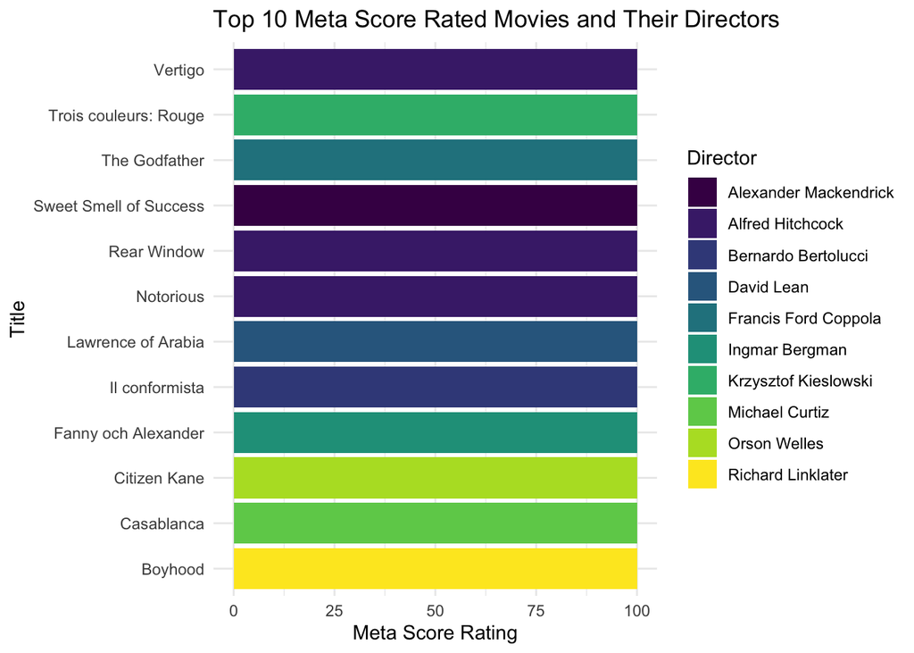

```r
# There are 12 metascore that are 100, all 12 of them have male directors
metatop12 %>%
  ggplot(aes(x = Meta_score, y = fct_reorder(Series_Title, desc(Meta_score)), fill = Director)) +
  geom_col() +
  labs(title = "Top 10 Meta Score Rated Movies and Their Directors", fill = "Director") +
  xlab("Meta Score Rating") +
  ylab("Title") +
  scale_fill_viridis_d() +
  theme_minimal()
```

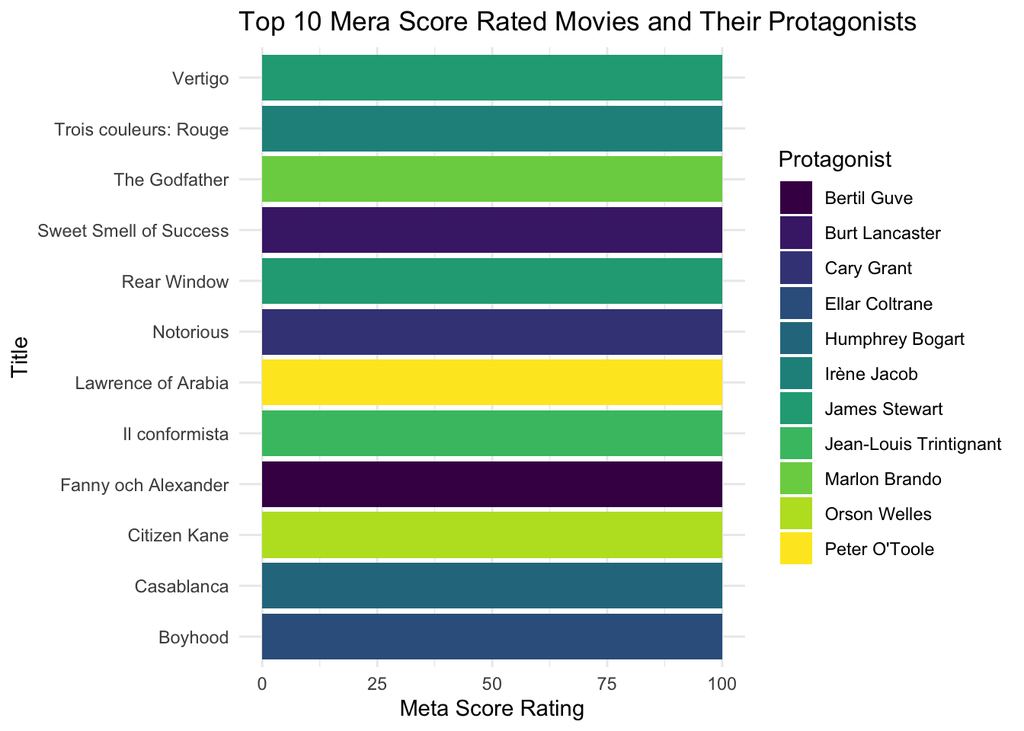

```r
# 11 out of the 12 have male protagonists
metatop12 %>%
  ggplot(aes(x = Meta_score, y = fct_reorder(Series_Title, desc(Meta_score)), fill = Star1)) +
  geom_col() +
  labs(title = "Top 10 Mera Score Rated Movies and Their Protagonists", fill = "Protagonist") +
  xlab("Meta Score Rating") +
  ylab("Title") +
  scale_fill_viridis_d() +
  theme_minimal()
```

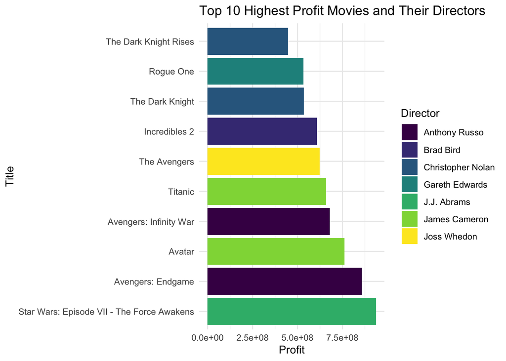

```r
# For movies that made the most money, all directors male
imdbrevtop10 %>%
  ggplot(aes(x = money, y = fct_reorder(Series_Title, desc(money)), fill = Director)) +
  geom_col() +
  labs(title = "Top 10 Highest Profit Movies and Their Directors", fill = "Director") +
  xlab("Profit") +
  ylab("Title") +
  scale_fill_viridis_d() +
  theme_minimal()
```

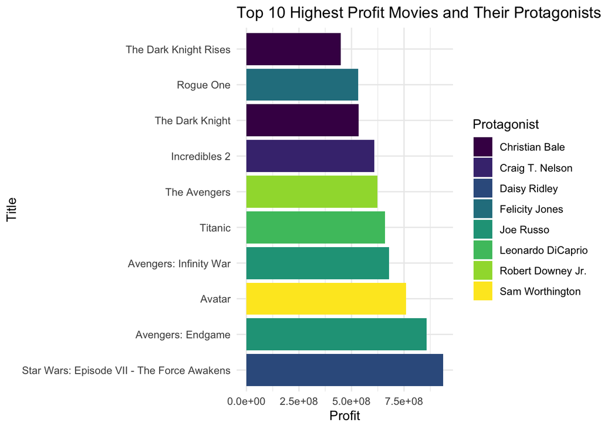

```r
# For movies that made the most money, 8 out of 10 protagonists are male
imdbrevtop10 %>%
  ggplot(aes(x = money, y = fct_reorder(Series_Title, desc(money)), fill = Star1)) +
  geom_col() +
  labs(title = "Top 10 Highest Profit Movies and Their Protagonists", fill = "Protagonist") +
  xlab("Profit") +
  ylab("Title") +
  scale_fill_viridis_d() +
  theme_minimal()
```

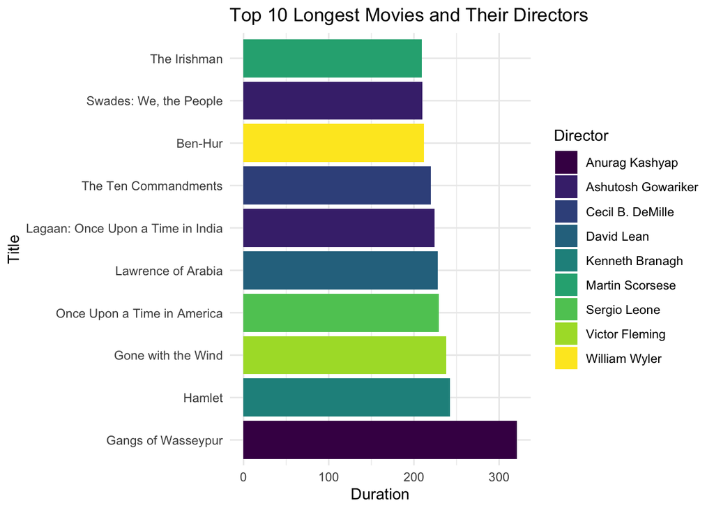

```r
# For the longest movies, all directors male
durationtop10 %>%
  ggplot(aes(x = duration, y = fct_reorder(Series_Title, desc(duration)), fill = Director)) +
  geom_col() +
  labs(title = "Top 10 Longest Movies and Their Directors", fill = "Director") +
  xlab("Duration") +
  ylab("Title") +
  scale_fill_viridis_d() +
  theme_minimal()
```

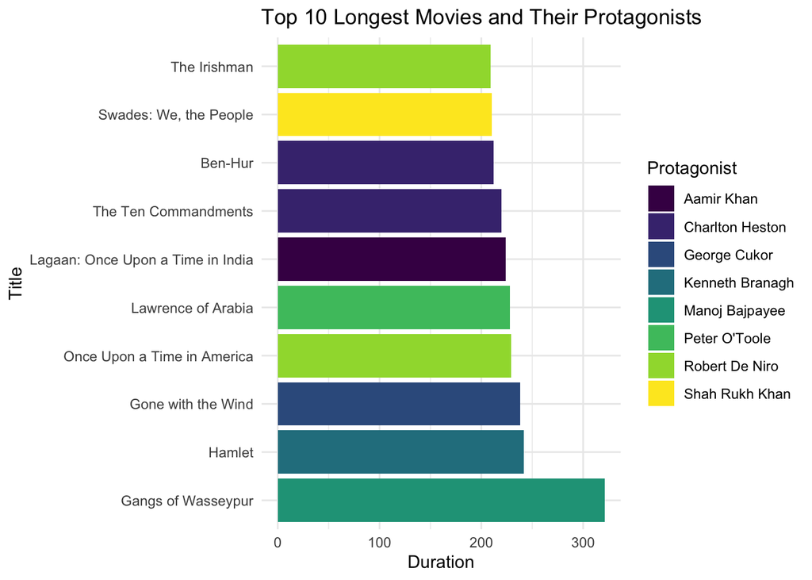

```r
# For the longest movies, all male protagonists
durationtop10 %>%
  ggplot(aes(x = duration, y = fct_reorder(Series_Title, desc(duration)), fill = Star1)) +
  geom_col() +
  labs(title = "Top 10 Longest Movies and Their Protagonists", fill = "Protagonist") +
  xlab("Duration") +
  ylab("Title") +
  scale_fill_viridis_d() +
  theme_minimal()
```

```r
academy_awards <- read_excel("oscars 2.xlsx")
head(academy_awards)
```

```
## # A tibble: 6 × 9
##   year_film year_ceremony ceremony Category     gender name   Race  film  winner
##       <dbl>         <dbl>    <dbl> <chr>        <chr>  <chr>  <chr> <chr> <lgl>
## 1      1927          1928        1 Best Actor   Male   Emil … White The … TRUE
## 2      1927          1928        1 Best Actress Female Janet… White 7th … TRUE
## 3      1928          1929        2 Best Actor   Male   Warne… White In O… TRUE
## 4      1928          1929        2 Best Actress Female Mary … White Coqu… TRUE
## 5      1929          1930        3 Best Actor   Male   Georg… White Disr… TRUE
## 6      1929          1930        3 Best Actress Female Norma… White The … TRUE
```

```r
academy_awards %>%
  count(gender)
```

```
## # A tibble: 3 × 2
##   gender     n
##   <chr>  <int>
## 1 Female  2125
## 2 Male    8270
## 3 female     1
```

This dataset has information on the Oscar Academy Awards from 1927 to 2020. The data was collected by Dharmik Donga, who wanted to visualize the diversity in academy awards. The variables include the film name, the year the film was created, Oscar Ceremony number, category for which it was nominated, gender (!!), race, and winner (True for winners, False for nominees). Of course, gender is our ideal variable here, so I would like to visualize something with gender. There are 10396 observations of 9 variables.

```r
# Filter to get only winners of the academy award, 2357 total.
winners <- academy_awards %>%
  subset(winner == "TRUE") %>%
  mutate(gender1 = as.factor(gsub("female","Female",gender)))
head(winners)
```

```
## # A tibble: 6 × 10
##   year_film year_ceremony ceremony Category     gender name   Race  film  winner
##       <dbl>         <dbl>    <dbl> <chr>        <chr>  <chr>  <chr> <chr> <lgl>
## 1      1927          1928        1 Best Actor   Male   Emil … White The … TRUE
## 2      1927          1928        1 Best Actress Female Janet… White 7th … TRUE
## 3      1928          1929        2 Best Actor   Male   Warne… White In O… TRUE
## 4      1928          1929        2 Best Actress Female Mary … White Coqu… TRUE
## 5      1929          1930        3 Best Actor   Male   Georg… White Disr… TRUE
## 6      1929          1930        3 Best Actress Female Norma… White The … TRUE
## # ℹ 1 more variable: gender1 <fct>
```

```r
winners %>%
  count(gender1)
```

```
## # A tibble: 2 × 2
##   gender1     n
##   <fct>   <int>
## 1 Female    462
## 2 Male     1895
```

```r
awards <- academy_awards %>%
  mutate(gender1 = as.factor(gsub("female","Female",gender)))

awards %>%
  count(gender1)
```

```
## # A tibble: 2 × 2
##   gender1     n
##   <fct>   <int>
## 1 Female   2126
## 2 Male     8270
```

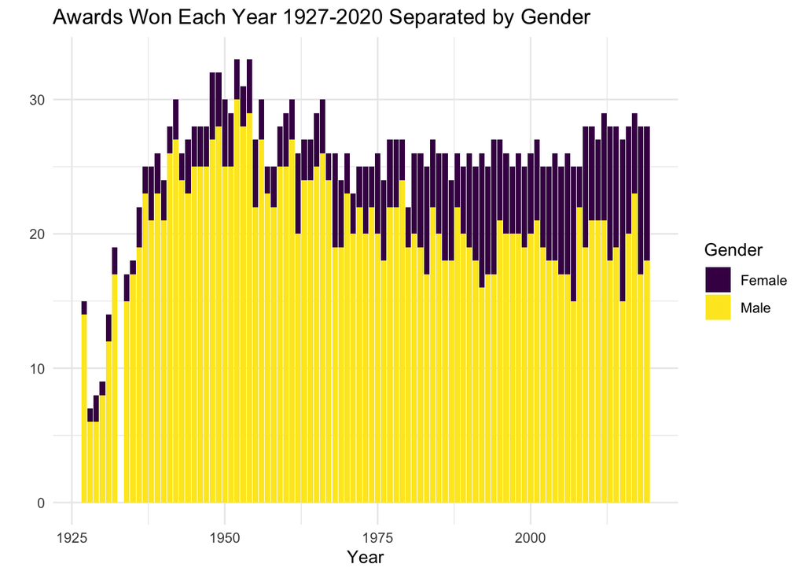

```r
# looking at the winners, we can see that the percentage of female winners increases out of total winners over time
winners %>%
  ggplot(aes(x = year_film, fill = gender1)) +
  geom_bar() +
  labs(title = "Awards Won Each Year 1927-2020 Separated by Gender", fill = "Gender") +
  xlab("Year") +
  ylab("") +
  scale_fill_viridis_d() +
  theme_minimal()
```

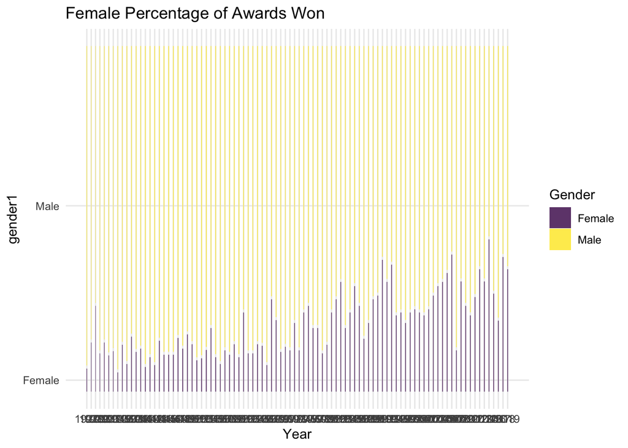

```r
mosaicstuff <- ggplot(data = winners) +
  geom_mosaic(aes(x = product(year_film), fill = gender1)) +
  labs(title = "Female Percentage of Awards Won", fill = "Gender") +
  xlab("Year") +
  scale_fill_viridis_d() +
  theme_minimal()

mosaicstuff
```